# bak_lab2

Jakub Bąk

25 10 2020

# Zadania na drugie laboratorium

## Przygotowanie danych

Zadanie 1: Pobierz do swojego katalogu roboczego dane Train_BMS.csv dołączone do opisu zadania i przypisz je do zmiennej train_BMS

```r
Train_BMS <- read.csv("./data/Train_BMS.csv", sep=",", header=TRUE, nrow= 8524, dec = ".", na.strings = " ")
```

Zadanie 2: Przyglądnij się danym. W tym celu wyświetl podsumowanie danych oraz nary- suj histogramy dla zmiennych numerycznych oraz kategorialnych (w tym drugim przypadku skorzystaj z biblioteki dplyr do grupowania danych w kategoriach)

```r
library(dplyr)
```

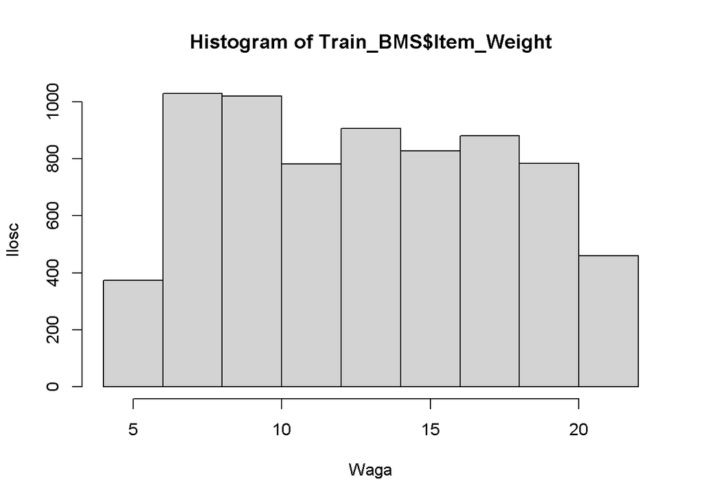

```r
hist(Train_BMS$Item_Weight, breaks=10, ylab="Ilosc", xlab="Waga")
```

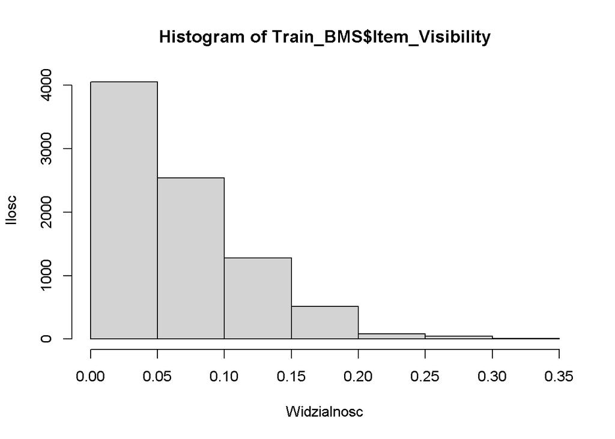

```r
hist(Train_BMS$Item_Visibility, breaks=10, ylab="Ilosc", xlab="Widzialnosc")
```

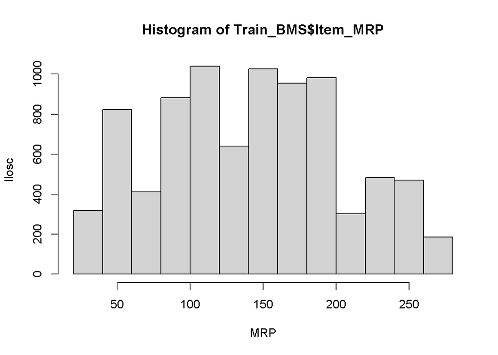

```r
hist(Train_BMS$Item_MRP, breaks=10, ylab="Ilosc", xlab="MRP")
```

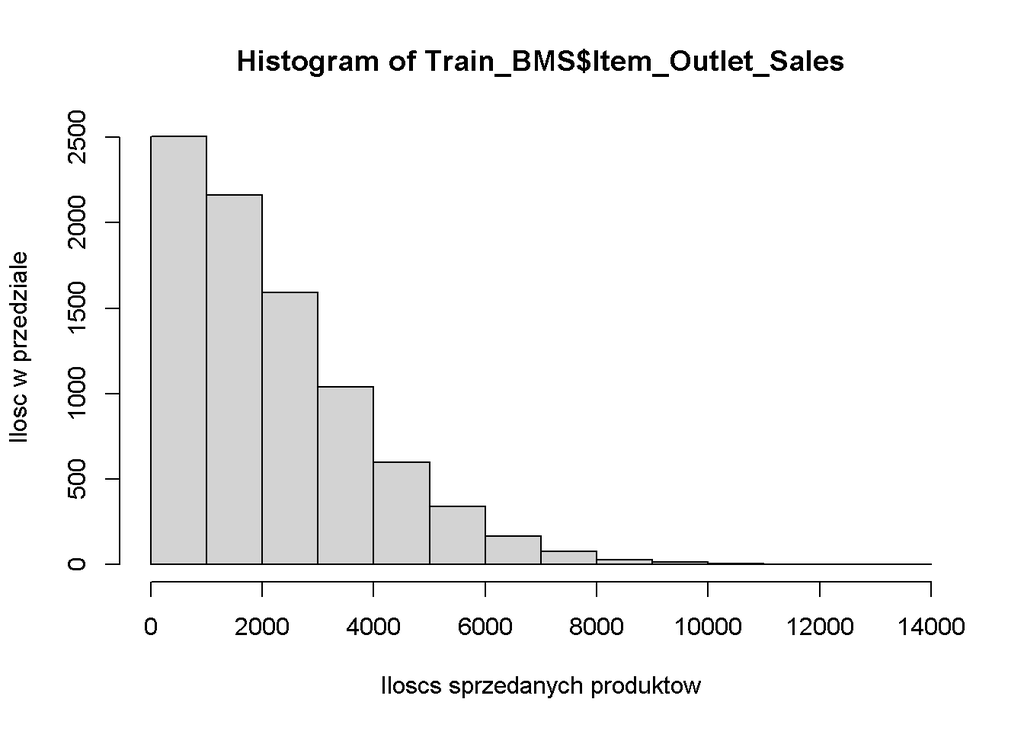

```r
hist(Train_BMS$Item_Outlet_Sales, breaks=10, ylab=" Ilosc w przedziale", xlab="Iloscs sprzedanych produktow")
```

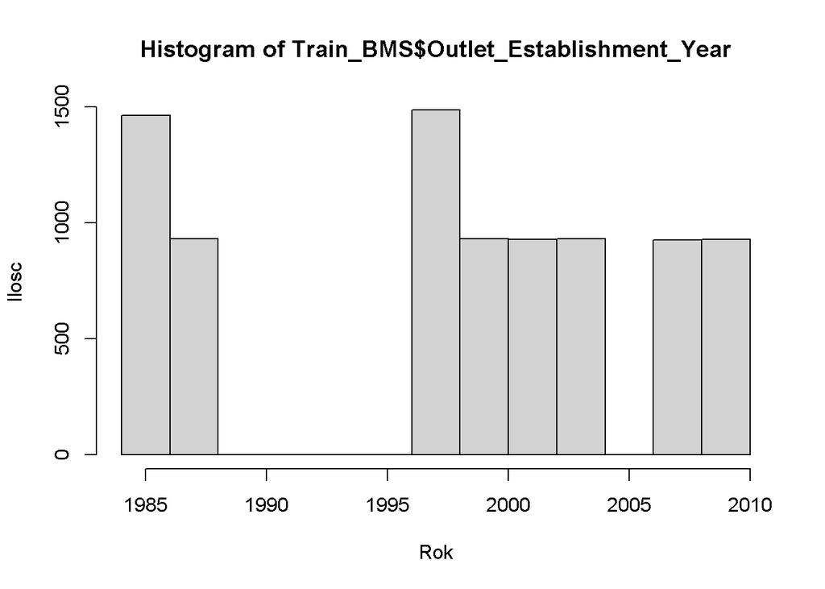

```r
hist(Train_BMS$Outlet_Establishment_Year, breaks=10, ylab="Ilosc", xlab="Rok")
```

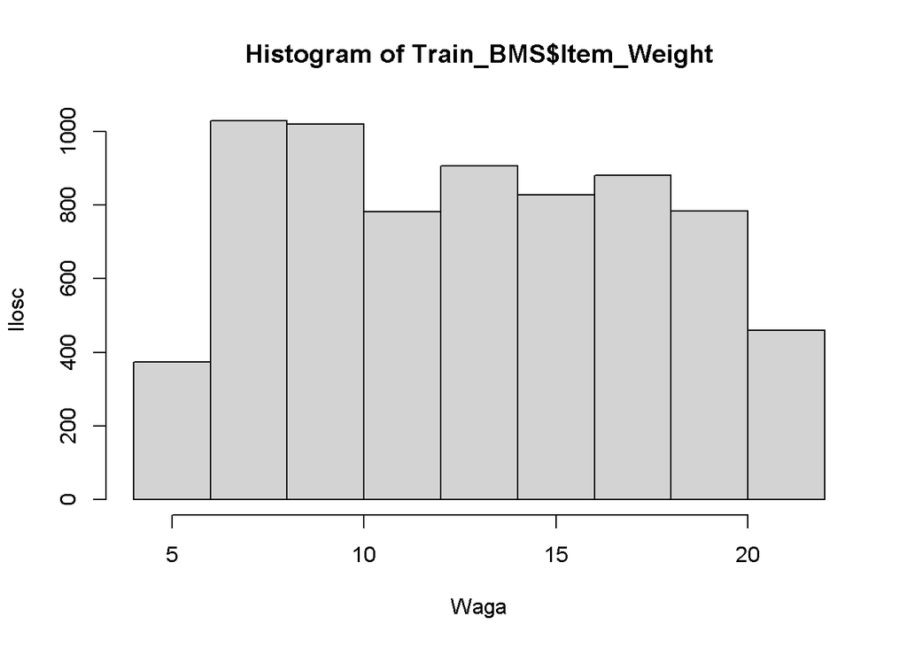

```r
hist(Train_BMS$Item_Weight, breaks=10, ylab="Ilosc", xlab="Waga")
```

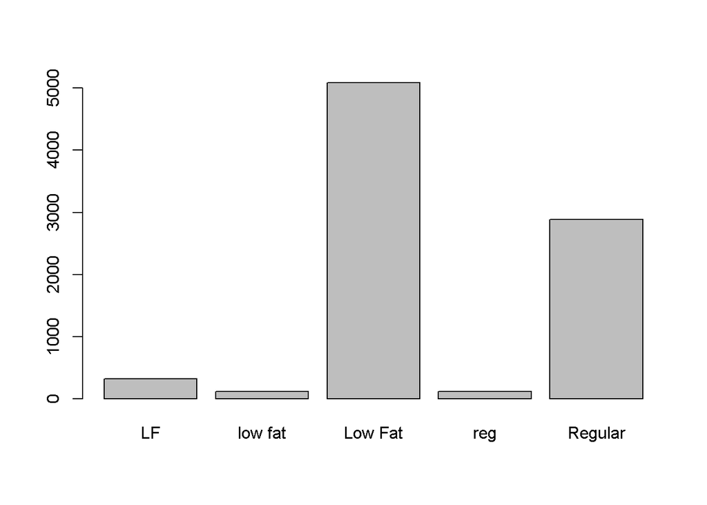

```r
barplot(table(Train_BMS$Item_Fat_Content))
```

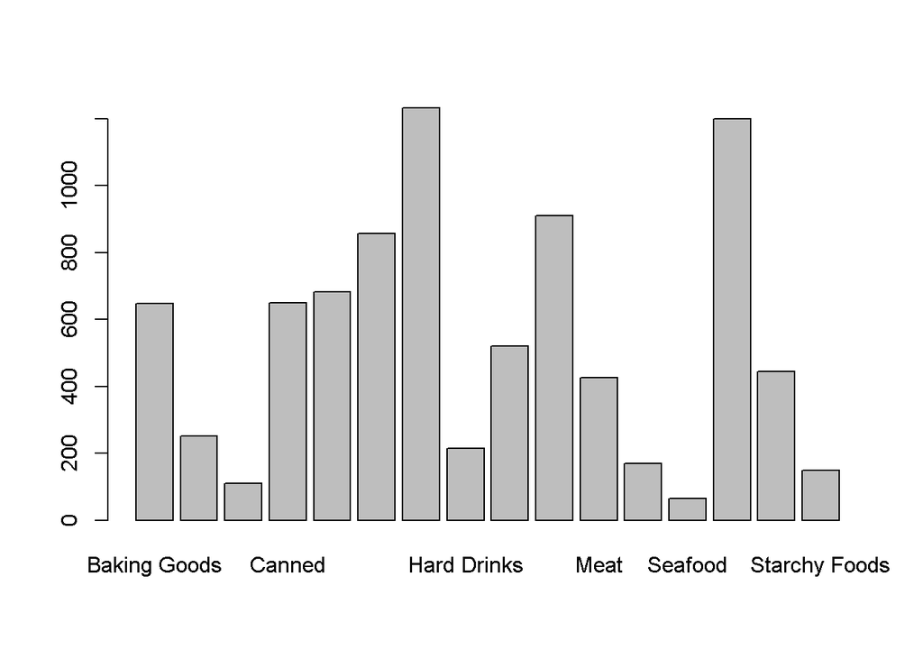

```r
barplot(table(Train_BMS$Item_Type))
```

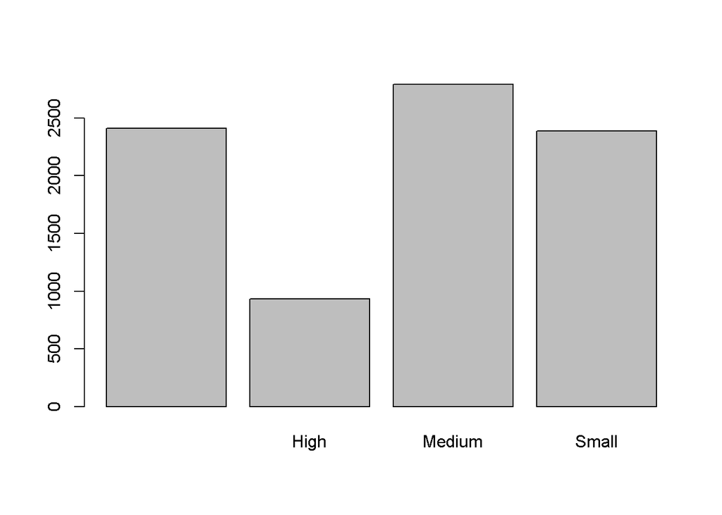

```r
barplot(table(Train_BMS$Outlet_Size))
```

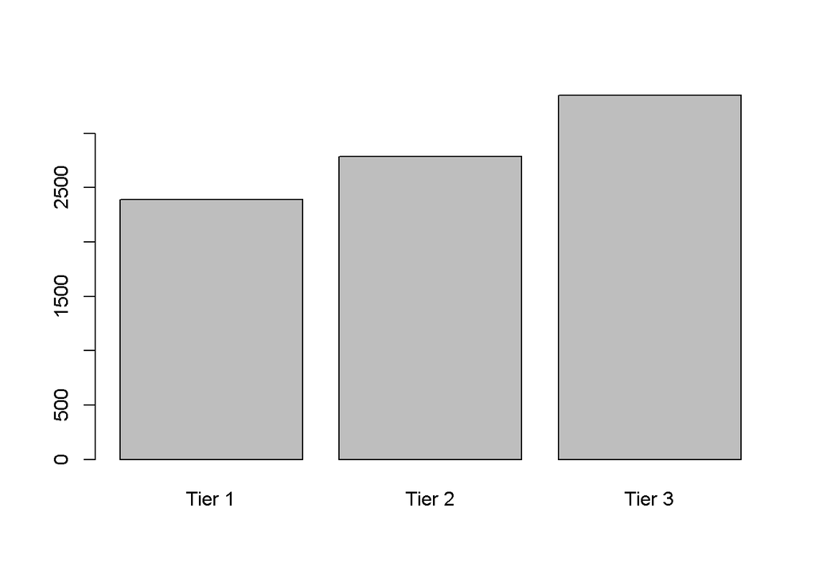

```r
barplot(table(Train_BMS$Outlet_Location_Type))
```

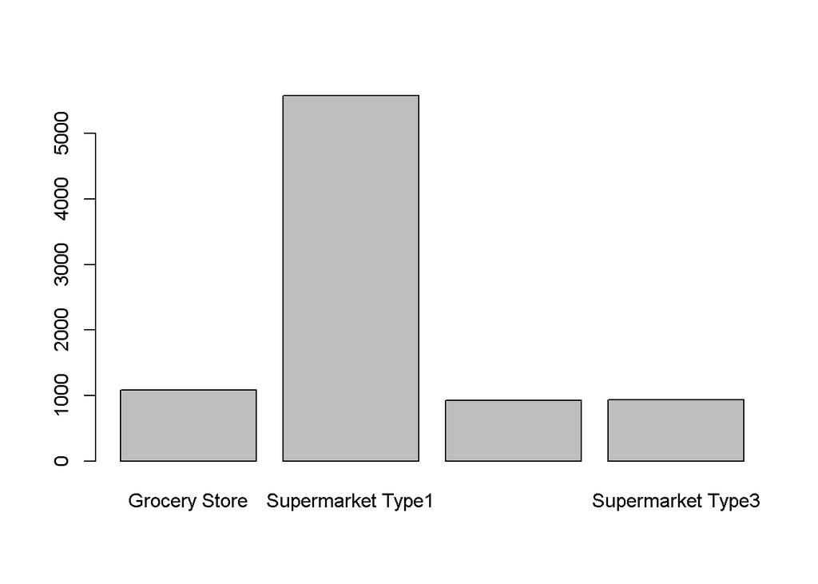

```r
barplot(table(Train_BMS$Outlet_Type))
```

Zadanie 3: Zauważ, że kolumna Item_Weight ma brakujące wartości - przypisz w tych miejscach wartość mediany obliczoną dla tej zmiennej.

```r
Item_Weight_Median <- median(Train_BMS$Item_Weight, na.rm = TRUE)
Train_BMS$Item_Weight[is.na(Train_BMS$Item_Weight)] <- Item_Weight_Median
```

Zadanie 4: Wartości zerowe w kolumnie Item_Visibility również zastąp medianą dla tej kolumny.

```r
Item_Visibility_Median <- median(Train_BMS$Item_Visibility, na.rm = TRUE)
Train_BMS$Item_Visibility[Train_BMS$Item_Visibility == 0] <- Item_Visibility_Median
```

Zadanie 5: Wykonaj poniższe polecenia a następnie napisz w sprawozdaniu co robią polecenia table oraz levels.

```r
table(Train_BMS$Outlet_Size, Train_BMS$Outlet_Type)
```

```
##
##          Grocery Store Supermarket Type1 Supermarket Type2 Supermarket Type3
##                    555              1855                 0                 0
##   High               0               932                 0                 0
##   Medium             0               930               928               935
##   Small            528              1860                 0                 0
```

```r
levels(Train_BMS$Outlet_Size)[1] <- "Other"
levels(Train_BMS$Outlet_Size)
```

```
## [1] "Other"
```

Komentarz:

- Funkcja ‘table’ sluzy do zliczania pojawien sie poszczegolnych kategorii w danej kolumnie lub kolumnach, a nastepnie zestawieniu ich. Moze przedstawiac zestawienie jednowymiarowe, jak i dwuwymiarowe w zaleznosci od jej zdefiniowania
- Funkcja ‘levels’ natomiast jest wykorzystywana do nadawania danym nowych, okreslonych przez nas kategorii dla danych. Domyslnie jest on NULLem, dopoki nie zostanie inaczej zdefiniowana.

Zadanie 6: Usuń z danych zmienne zależne (kolumny Item_Outlet_Sales oraz Item_Identifier). Zmodyfikowaną ramkę danych przypisz zmiennej my_data i sprawdź, jakie zmienne pozostały.

```r
my_data <- Train_BMS[-c(1,12)]
names(my_data)
```

```
##  [1] "Item_Weight"               "Item_Fat_Content"
##  [3] "Item_Visibility"           "Item_Type"
##  [5] "Item_MRP"                  "Outlet_Identifier"
##  [7] "Outlet_Establishment_Year" "Outlet_Size"
##  [9] "Outlet_Location_Type"      "Outlet_Type"
```

Aktualny rozmiar macierzy: 8523 x 10

Zadanie 7: Zauważ, że w zmiennej Item_Fat_Content występują różne nazwy na te same kategorie. Złącz je ze sobą.

```r
my_data$Item_Fat_Content <- gsub("low fat", "Low Fat", my_data$Item_Fat_Content)
my_data$Item_Fat_Content <- gsub("LF", "Low Fat", my_data$Item_Fat_Content)
my_data$Item_Fat_Content <- gsub("reg", "Regular", my_data$Item_Fat_Content)
```

Zadanie 8: Przekształć zmienne kategorialne w liczbowe. Wykorzystaj w tym celu bibliotekę dummies.

```r
library("dummies")
new_my_data <- dummy.data.frame(my_data, names = c("Item_Fat_Content","Item_Type", "Outlet_Establishment_Year","Outlet_Size", "Outlet_Location_Type", "Outlet_Type"))
```

## PCA

Zadanie 1: Na tak przygotowanych danych wykonaj PCA za pomocą funkcji prcomp(). Zastosuj parametr scale .= T aby znormalizować zmienne (aby odchylenie standardowe wynosiło 1). Wynik działania funkcji prcomp() zapisz do zmiennej PCA_train.

```r
new_my_data <- new_my_data[-c(22)]
## Usuwam zmienna "Outlet_Identifier", aby moc prawidlowo przeprowadzic PCA
PCA_train <- prcomp(new_my_data, scale. = T)
summary(PCA_train)
```

```
## Importance of components:
##                           PC1     PC2     PC3     PC4     PC5     PC6     PC7
## Standard deviation     2.1364 1.79421 1.65654 1.59201 1.52319 1.42118 1.39043
## Proportion of Variance 0.1113 0.07852 0.06693 0.06182 0.05659 0.04926 0.04715
## Cumulative Proportion  0.1113 0.18984 0.25677 0.31858 0.37517 0.42443 0.47159
##                            PC8     PC9    PC10    PC11    PC12    PC13   PC14
## Standard deviation     1.12506 1.09737 1.08010 1.07401 1.05743 1.04983 1.0443
## Proportion of Variance 0.03087 0.02937 0.02845 0.02813 0.02727 0.02688 0.0266
## Cumulative Proportion  0.50246 0.53183 0.56029 0.58842 0.61569 0.64257 0.6692
##                           PC15    PC16    PC17    PC18   PC19    PC20    PC21
## Standard deviation     1.04352 1.04025 1.03296 1.02224 1.0166 1.01338 1.01092
## Proportion of Variance 0.02656 0.02639 0.02602 0.02549 0.0252 0.02505 0.02493
## Cumulative Proportion  0.69573 0.72212 0.74815 0.77364 0.7988 0.82389 0.84881
##                           PC22    PC23    PC24    PC25    PC26    PC27    PC28
## Standard deviation     1.00866 1.00329 0.96339 0.95432 0.93947 0.87407 0.83021
## Proportion of Variance 0.02481 0.02455 0.02264 0.02221 0.02153 0.01863 0.01681
## Cumulative Proportion  0.87363 0.89818 0.92082 0.94303 0.96456 0.98319 1.00000
##                            PC29      PC30      PC31      PC32      PC33
## Standard deviation     1.04e-14 4.759e-15 4.355e-15 3.557e-15 3.236e-15
## Proportion of Variance 0.00e+00 0.000e+00 0.000e+00 0.000e+00 0.000e+00
## Cumulative Proportion  1.00e+00 1.000e+00 1.000e+00 1.000e+00 1.000e+00
##                             PC34      PC35      PC36      PC37      PC38
## Standard deviation     2.551e-15 2.414e-15 1.991e-15 1.624e-15 8.058e-16
## Proportion of Variance 0.000e+00 0.000e+00 0.000e+00 0.000e+00 0.000e+00
## Cumulative Proportion  1.000e+00 1.000e+00 1.000e+00 1.000e+00 1.000e+00
##                             PC39      PC40      PC41
## Standard deviation     7.155e-16 5.722e-16 1.761e-16
## Proportion of Variance 0.000e+00 0.000e+00 0.000e+00
## Cumulative Proportion  1.000e+00 1.000e+00 1.000e+00
```

Zadanie 2: –

Zadanie 3: Wykonaj dwa wykresy: wykres procentu wariancji wyjaśnionej przez każdy ze składników PCA oraz skumulowany procent wariancji wyjaśnionej przez każdy ze składników PCA.

```r
PCA_train_sdev <- summary(PCA_train)$importance[1,]
PCA_train_sdev[1:3]
```

```
##      PC1      PC2      PC3
## 2.136386 1.794210 1.656543
```

```r
PCA_train_var <- PCA_train_sdev^2
PCA_train_var[1:4]
```

```
##      PC1      PC2      PC3      PC4
## 4.564147 3.219190 2.744135 2.534485
```

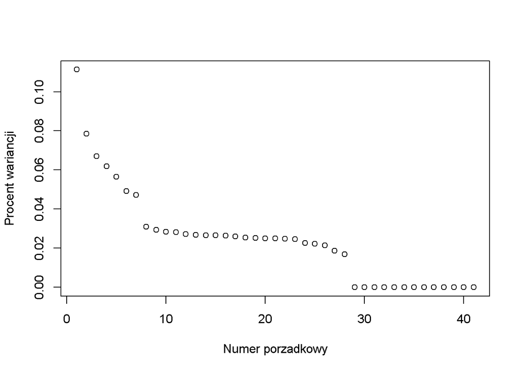

```r
PCA_train_PoV <- PCA_train_var/sum(PCA_train_var)
plot(PCA_train_PoV, xlab = "Numer porzadkowy", ylab = "Procent wariancji")
```

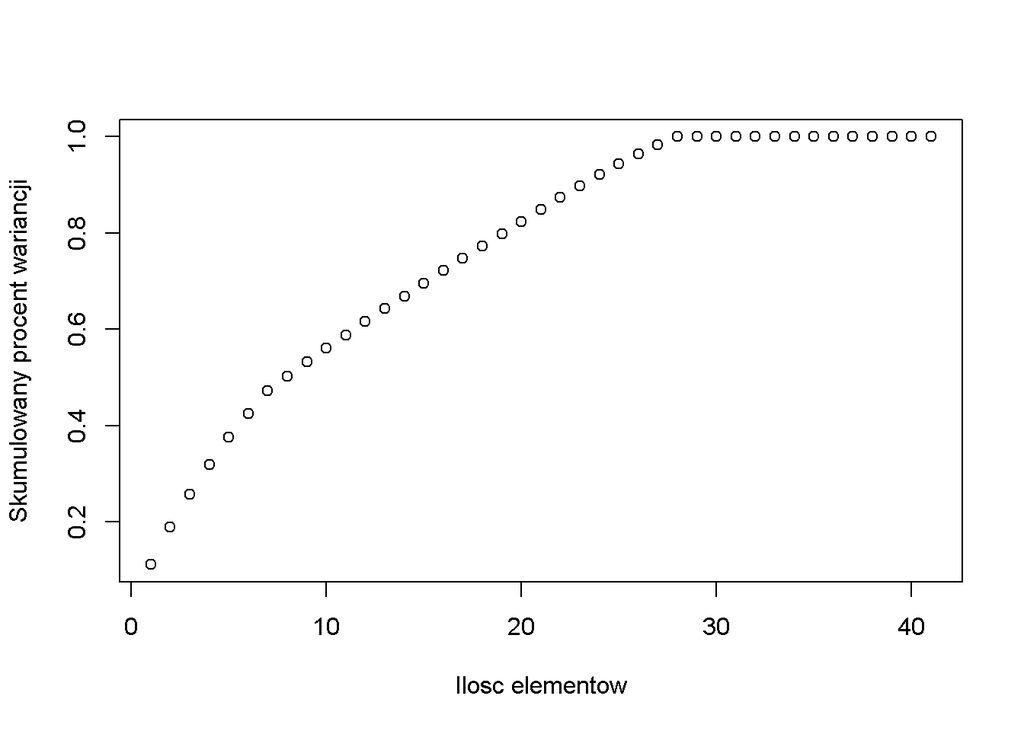

```r
plot(cumsum(PCA_train_PoV), xlab = "Ilosc elementow", ylab = "Skumulowany procent wariancji")
```

```r
Cumulative_percentage <- summary(PCA_train)$importance[3,][27]
Cumulative_percentage
```

```
##    PC27
## 0.98319
```

- 98% wariancji jest tlumaczonych przez pierwsze 27 skladnikow, a jego dokladna wartosc wynosi 0.98319

Zadanie 4: Zastosowania metody PCA

PCA jest uzywana przede wszystkim do zmniejszenia rozmiaru zbioru danych statystycznych. Pomaga rowniez przy interpretacji czynnikow w zbiorze, co pozwoli na ich lepsze zrozumienie. Stosuje sie ja takze do odkrywania pewnych prawidlowosci miedzy zmiennymi. Jest rowniez wykorzystywana przy kompresji sygnalu.